# Self directed activities 10 all qs

Josh Copeland (SID: 1444772)

2025-10-13

```r
#Packages used:

# library(tidyverse)
# library(lubridate)
# library(janitor)
# library(forecast)
```

# Q1

Previously we found an AR(3) model is an appropriate conditional mean model for the interest rates on 3 month Bank Accepted Bills, Jan-2010 to Jun-2024.

Set up the data in the usual way.

```r
dt <- read.csv("BAB3mth.csv")
Y <- ts(dt$BAB3, start=c(2010,1), end=c(2025,6), frequency=12)
DY <- diff(Y)

# Forecast sample c(2024,7) to c(2025,6)
DYf <- window(DY, start=c(2024,7), end=c(2025,6))
Timef <- time(DYf)
hmax <- length(DYf)

# Estimation sample c(2010,1) to c(2024,6)
DY <- window(DY, end=c(2024,6))
Time <- time(DY)
```

### (a)

Estimate an AR(3)-ARCH(1) model for DY, and show the results.

```r
AR3ARCH1 <- ugarchfit(data=DY,
    ugarchspec(variance.model=list(garchOrder=c(1,0)),
               mean.model=list(armaOrder=c(3,0))))
show(AR3ARCH1)
```

```
##
## *---------------------------------*
## *          GARCH Model Fit        *
## *---------------------------------*
##
## Conditional Variance Dynamics
## -----------------------------------
## GARCH Model  : sGARCH(1,0)
## Mean Model   : ARFIMA(3,0,0)
## Distribution : norm
##
## Optimal Parameters
## ------------------------------------
##         Estimate  Std. Error  t value Pr(>|t|)
## mu      0.026052    0.017944   1.4519 0.146535
## ar1     0.604035    0.079021   7.6440 0.000000
## ar2    -0.083503    0.076908  -1.0858 0.277588
## ar3     0.166147    0.050876   3.2657 0.001092
## omega   0.004549    0.000838   5.4254 0.000000
## alpha1  0.827706    0.234543   3.5290 0.000417
##
## Robust Standard Errors:
##         Estimate  Std. Error  t value Pr(>|t|)
## mu      0.026052    0.021048   1.2377 0.215817
## ar1     0.604035    0.072189   8.3674 0.000000
## ar2    -0.083503    0.066553  -1.2547 0.209593
## ar3     0.166147    0.036839   4.5100 0.000006
## omega   0.004549    0.002428   1.8735 0.060994
## alpha1  0.827706    0.437332   1.8926 0.058408
##
## LogLikelihood : 159.3003
##
## Information Criteria
## ------------------------------------
##
## Akaike       -1.7723
## Bayes        -1.6629
## Shibata      -1.7746
## Hannan-Quinn -1.7279
##
```

[output cut: 43 more lines]

```
## Negative Sign Bias  0.9972 0.32010
## Positive Sign Bias  0.5896 0.55626
## Joint Effect        3.0917 0.37769
##
##
## Adjusted Pearson Goodness-of-Fit Test:
## ------------------------------------
##   group statistic p-value(g-1)
## 1    20     30.82       0.0423
## 2    30     31.45       0.3445
## 3    40     45.96       0.2061
## 4    50     45.79       0.6042
##
##
## Elapsed time : 0.2031672
```

### (b)

Extracting the ARCH LM tests is a bit fiddly. Surprisingly it appears there is not a specific ARCH LM test method in rugarch, as there is for AIC for eg. Doing the following is easier for current purposes than coding up the test or bringing in a different package with lesser capabilities in other dimensions.

```r
summaryAR3ARCH1 <- capture.output(show(AR3ARCH1))
r1 <- which(summaryAR3ARCH1=="Weighted ARCH LM Tests")
r2 <- which(summaryAR3ARCH1=="Nyblom stability test")-2
ARCHLMtests <- summaryAR3ARCH1[r1:r2]
print(ARCHLMtests, quote="FALSE")
```

```
## [1] Weighted ARCH LM Tests
## [2] ------------------------------------
## [3]             Statistic Shape Scale P-Value
## [4] ARCH Lag[2]    0.1092 0.500 2.000  0.7411
## [5] ARCH Lag[4]    0.4192 1.397 1.611  0.8940
## [6] ARCH Lag[6]    0.5775 2.222 1.500  0.9628
```

### (c)

Compare the AIC of the AR(3)-ARCH(1) model to that of the AR(3) model to check whether including the ARCH model produces an improvement in fit.

```r
print(infocriteria(AR3ARCH1))
```

```
##
## Akaike       -1.772258
## Bayes        -1.662895
## Shibata      -1.774558
## Hannan-Quinn -1.727890
```

```r
cat(paste0("AIC AR3        = ",
   round(Arima(DY, order=c(3,0,0))$aic,2),
   "\n"))
```

```
## AIC AR3        = -266.97
```

```r
cat(paste0("AIC AR3ARCH1   = ",
   round(infocriteria(AR3ARCH1)[1]*length(DY),2),
   "\n"))
```

```
## AIC AR3ARCH1   = -306.6
```

### (d)

Estimate an AR(3)-GARCH(1,1) model. Check the ARCH LM tests and use AIC to compare to the AR(3) and AR(3)-ARCH(1) models.

```r
# Fit AR(3)–GARCH(1,1)
AR3GARCH11 <- ugarchfit(
  data = DY,
  ugarchspec(
    variance.model = list(garchOrder = c(1, 1)),
    mean.model     = list(armaOrder  = c(3, 0))
  )
)
show(AR3GARCH11)
```

```
##
## *---------------------------------*
## *          GARCH Model Fit        *
## *---------------------------------*
##
## Conditional Variance Dynamics
## -----------------------------------
## GARCH Model  : sGARCH(1,1)
## Mean Model   : ARFIMA(3,0,0)
## Distribution : norm
##
## Optimal Parameters
## ------------------------------------
##         Estimate  Std. Error  t value Pr(>|t|)
## mu      0.014091    0.024880  0.56636 0.571148
## ar1     0.639744    0.076204  8.39516 0.000000
## ar2    -0.145080    0.089449 -1.62193 0.104819
## ar3     0.185819    0.075436  2.46325 0.013769
## omega   0.000264    0.000090  2.92347 0.003462
## alpha1  0.000000    0.005924  0.00000 1.000000
## beta1   0.976086    0.022732 42.93817 0.000000
##
## Robust Standard Errors:
##         Estimate  Std. Error  t value Pr(>|t|)
## mu      0.014091    0.032772  0.42998 0.667213
## ar1     0.639744    0.125880  5.08217 0.000000
## ar2    -0.145080    0.120674 -1.20224 0.229270
## ar3     0.185819    0.065376  2.84232 0.004479
## omega   0.000264    0.000427  0.61898 0.535929
## alpha1  0.000000    0.005163  0.00000 1.000000
## beta1   0.976086    0.040247 24.25267 0.000000
##
## LogLikelihood : 137.8462
##
## Information Criteria
## ------------------------------------
##
## Akaike       -1.5127
## Bayes        -1.3851
## Shibata      -1.5158
```

[output cut: 46 more lines]

```
## Negative Sign Bias   2.730 7.016e-03 ***
## Positive Sign Bias   4.405 1.878e-05 ***
## Joint Effect        27.571 4.469e-06 ***
##
##
## Adjusted Pearson Goodness-of-Fit Test:
## ------------------------------------
##   group statistic p-value(g-1)
## 1    20     51.39    8.151e-05
## 2    30     55.03    2.455e-03
## 3    40     64.92    5.690e-03
## 4    50     90.87    2.596e-04
##
##
## Elapsed time : 0.0728209
```

```r
# Extract and print the "Weighted ARCH LM Tests" block from the summary
summaryAR3GARCH11 <- capture.output(show(AR3GARCH11))
r1 <- which(summaryAR3GARCH11 == "Weighted ARCH LM Tests")
r2 <- which(summaryAR3GARCH11 == "Nyblom stability test") - 2
ARCHLMtests_GARCH11 <- summaryAR3GARCH11[r1:r2]
print(ARCHLMtests_GARCH11, quote = "FALSE")
```

```
## [1] Weighted ARCH LM Tests
## [2] ------------------------------------
## [3]             Statistic Shape Scale P-Value
## [4] ARCH Lag[3]   0.05097 0.500 2.000  0.8214
## [5] ARCH Lag[5]   1.11112 1.440 1.667  0.7003
## [6] ARCH Lag[7]   1.32811 2.315 1.543  0.8551
```

```r
# AIC comparison (scale rugarch's AIC by length(DY) for apples-to-apples)
AIC_AR3          <- Arima(DY, order = c(3,0,0))$aic
AIC_AR3ARCH1     <- infocriteria(AR3ARCH1)[1] * length(DY)
AIC_AR3GARCH11   <- infocriteria(AR3GARCH11)[1] * length(DY)

cat(paste0(
  "AIC AR(3)              = ", round(AIC_AR3, 2), "\n",
  "AIC AR(3)-ARCH(1)      = ", round(AIC_AR3ARCH1, 2), "\n",
  "AIC AR(3)-GARCH(1,1)   = ", round(AIC_AR3GARCH11, 2), "\n"
))
```

```
## AIC AR(3)              = -266.97
## AIC AR(3)-ARCH(1)      = -306.6
## AIC AR(3)-GARCH(1,1)   = -261.69
```

### (e)

Produce forecasts for each month of Jul-2024 to Jun-2025. Show the point forecasts, standard deviation forecasts, and associated 95% prediction intervals. Plot these, and compare with the AR(3) forecasts and prediction intervals.

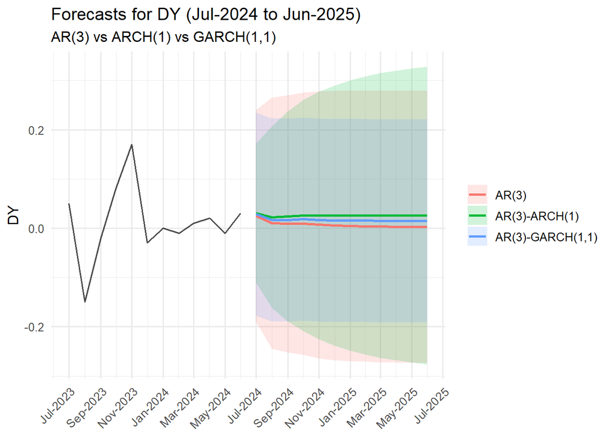

```r
# h step ahead forecasts AR3-ARCH1

h <- length(DYf)
fc_dates <- seq(as.Date("2024-07-01"), by = "1 month", length.out = h)

fit_ar3 <- Arima(DY, order = c(3,0,0))
fc_ar3  <- forecast(fit_ar3, h = h)
df_ar3 <- tibble(
  date  = fc_dates,
  model = "AR(3)",
  mean  = as.numeric(fc_ar3$mean),
  lower = as.numeric(fc_ar3$lower[,"95%"]),
  upper = as.numeric(fc_ar3$upper[,"95%"])
)

fc_arch1 <- ugarchforecast(AR3ARCH1, n.ahead = h)
df_arch1 <- tibble(
  date  = fc_dates,
  model = "AR(3)-ARCH(1)",
  mean  = as.numeric(fc_arch1@forecast$seriesFor),
  sd    = as.numeric(fc_arch1@forecast$sigmaFor)
) |> mutate(lower = mean - 1.96*sd, upper = mean + 1.96*sd)

fc_garch <- ugarchforecast(AR3GARCH11, n.ahead = h)
df_garch <- tibble(
  date  = fc_dates,
  model = "AR(3)-GARCH(1,1)",
  mean  = as.numeric(fc_garch@forecast$seriesFor),
  sd    = as.numeric(fc_garch@forecast$sigmaFor)
) |> mutate(lower = mean - 1.96*sd, upper = mean + 1.96*sd)

fc_all <- bind_rows(
  select(df_ar3, date, model, mean, lower, upper),
  select(df_arch1, date, model, mean, lower, upper),
  select(df_garch, date, model, mean, lower, upper)
)

ts_to_df <- function(x){
  s <- tsp(x)[1]; sY <- floor(s); sM <- floor((s - sY)*12 + 0.5) + 1
  dates <- seq(as.Date(sprintf("%d-%02d-01", sY, sM)), by = "1 month", length.out = length(x))
  tibble(date = dates, value = as.numeric(x))
}
hist_df <- ts_to_df(DY) |> slice_tail(n = 12)

ggplot() +
  geom_line(data = hist_df, aes(date, value), linewidth = 0.6, alpha = 0.7) +
  geom_ribbon(data = fc_all, aes(date, ymin = lower, ymax = upper, fill = model), alpha = 0.18) +
  geom_line(data = fc_all, aes(date, mean, color = model), linewidth = 0.9) +
  labs(title = "Forecasts for DY (Jul-2024 to Jun-2025)",
       subtitle = "AR(3) vs ARCH(1) vs GARCH(1,1)",
       x = NULL, y = "DY") +
  scale_x_date(date_breaks = "2 months", date_labels = "%b-%Y") +
  theme_minimal(base_size = 12) +
  theme(axis.text.x = element_text(angle = 45, hjust = 1),
        legend.title = element_blank())
```

# Q2

Conditional heteroskedasticity is especially common in high frequency (eg. daily or weekly) financial time series. The rugarch package contains data on daily returns on the SP500 share index from 10-Mar-1987 to 30-Jan-2009. Here is how we can set up this data, using the last five days (business week) as the forecast period.

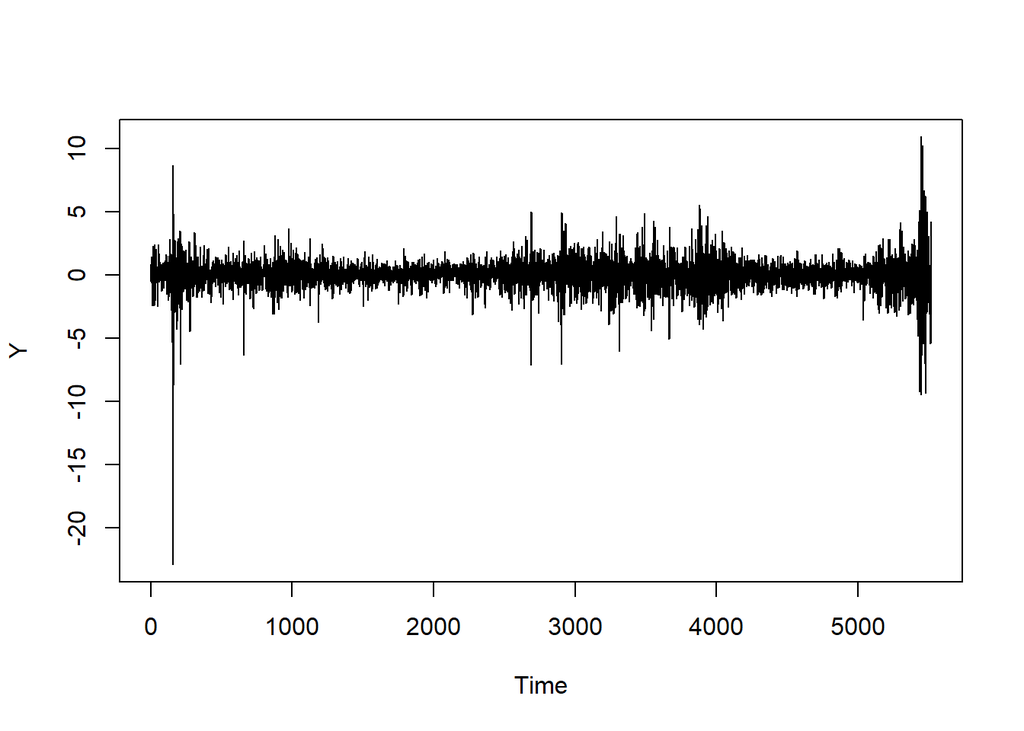

```r
data("sp500ret")
Y <- sp500ret$SP500RET*100

hmax <- 5
n <- length(Y)-hmax
Yf <- ts(Y[(n+1):length(Y)], start=n+1)
Y <- ts(Y[1:n])
plot(Y)
```

### (a)

Carry out an ARMA model selection search for this time series, using p_max=10 and q_max=2. Running this may take a minute, since ARMA model estimation with large sample sizes (over 5000) can take a bit longer.

```r
# Model selection
pmax <- 10
qmax <- 2

# Storage for AIC and LBp
M <- matrix(nrow=(1+pmax)*(1+qmax), ncol=4)
colnames(M) <- c("p","q","AICc","LBp")
rownames(M) <- 1:nrow(M)
M[,1] <- rep(0:pmax,each=1+qmax)
M[,2] <- rep(0:qmax,1+pmax)

m <- 1
for (p in 0:pmax){
  for (q in 0:qmax){
    # Estimate ARMA(p,q) model
    eq <- Arima(Y, order=c(p,0,q))

    # Store AIC and LB p-value
    M[m,"AICc"] <- eq$aicc
    M[m,"LBp"] <- round(Box.test(eq$residuals, lag=p+q+5,
                   type="Ljung-Box", fitdf=p+q)$p.value,4)
    m <- m+1
  }
}

# Restrict to models that pass LB test
M <- M[which(M[,"LBp"]>0.05),]

# Minimise AICc
m_AICc <- which.min(M[,"AICc"])
p <- M[m_AICc,"p"]
q <- M[m_AICc,"q"]
cat(paste0("p = ", p, ", q = " ,q))
```

```
## p = 5, q = 1
```

### (b)

Estimate the chosen model and plot the inverse roots. What does this plot suggest about the model specification?

- There is a root in both the AR and MA unit circles which are very close to its border. Each suggest nonstationarity and noninvertibility respectively, which means the model is not well specified and should not be used for forecasting.

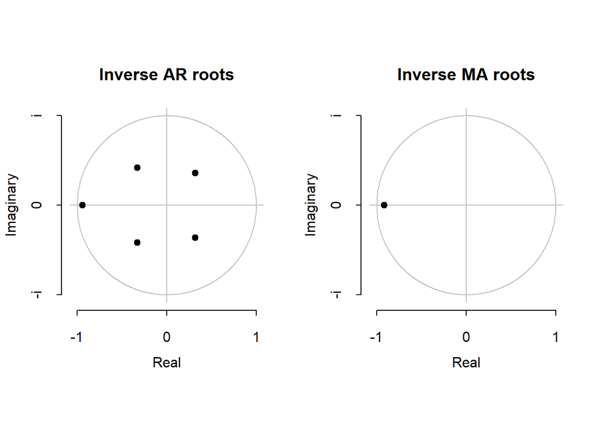

```r
p <- 5
q <- 1

ARMApq <- Arima(Y, order=c(p,0,q))
plot(ARMApq)
```

### (c)

Estimate AR(4)-ARCH(1) and AR(4)-GARCH(1,1) models for Y. Which of these two models is preferred, and why?

```r
# estimate and fitr
Y_est <- window(Y, end = c(2024, 6))

AR4ARCH1 <- ugarchfit(
  data = Y_est,
  ugarchspec(
    variance.model = list(garchOrder = c(1, 0)),
    mean.model     = list(armaOrder  = c(4, 0))
  )
)

AR4GARCH11 <- ugarchfit(
  data = Y_est,
  ugarchspec(
    variance.model = list(garchOrder = c(1, 1)),
    mean.model     = list(armaOrder  = c(4, 0))
  )
)
show(AR4GARCH11)
```

```
##
## *---------------------------------*
## *          GARCH Model Fit        *
## *---------------------------------*
##
## Conditional Variance Dynamics
## -----------------------------------
## GARCH Model  : sGARCH(1,1)
## Mean Model   : ARFIMA(4,0,0)
## Distribution : norm
##
## Optimal Parameters
## ------------------------------------
##         Estimate  Std. Error  t value Pr(>|t|)
## mu      0.047396    0.015227  3.11259 0.001855
## ar1     0.014947    0.025032  0.59713 0.550420
## ar2    -0.003401    0.024709 -0.13764 0.890524
## ar3    -0.036222    0.024480 -1.47963 0.138971
## ar4    -0.075179    0.024242 -3.10121 0.001927
## omega   0.027461    0.007453  3.68478 0.000229
## alpha1  0.117523    0.016032  7.33061 0.000000
## beta1   0.859179    0.020423 42.06827 0.000000
##
## Robust Standard Errors:
##         Estimate  Std. Error  t value Pr(>|t|)
## mu      0.047396    0.016972  2.79262 0.005228
## ar1     0.014947    0.026589  0.56217 0.573999
## ar2    -0.003401    0.022253 -0.15283 0.878531
## ar3    -0.036222    0.023580 -1.53614 0.124504
## ar4    -0.075179    0.026528 -2.83391 0.004598
## omega   0.027461    0.021957  1.25067 0.211055
## alpha1  0.117523    0.076498  1.53630 0.124465
## beta1   0.859179    0.080272 10.70334 0.000000
##
## LogLikelihood : -2525.395
##
## Information Criteria
## ------------------------------------
##
## Akaike       2.4972
```

[output cut: 49 more lines]

```
## Negative Sign Bias  3.17268 0.001533 ***
## Positive Sign Bias  0.98962 0.322480
## Joint Effect       15.10342 0.001730 ***
##
##
## Adjusted Pearson Goodness-of-Fit Test:
## ------------------------------------
##   group statistic p-value(g-1)
## 1    20     112.2    3.100e-15
## 2    30     120.3    4.311e-13
## 3    40     138.0    5.445e-13
## 4    50     151.5    2.108e-12
##
##
## Elapsed time : 0.230325
```

```r
# weighted ARCH LM tests

summaryAR4GARCH11 <- capture.output(show(AR4GARCH11))
r1 <- which(summaryAR4GARCH11 == "Weighted ARCH LM Tests")
r2 <- which(summaryAR4GARCH11 == "Nyblom stability test") - 2
ARCHLMtests_AR4GARCH11 <- summaryAR4GARCH11[r1:r2]
print(ARCHLMtests_AR4GARCH11, quote = "FALSE")
```

```
## [1] Weighted ARCH LM Tests
## [2] ------------------------------------
## [3]             Statistic Shape Scale P-Value
## [4] ARCH Lag[3]   0.05308 0.500 2.000  0.8178
## [5] ARCH Lag[5]   0.25094 1.440 1.667  0.9530
## [6] ARCH Lag[7]   0.70711 2.315 1.543  0.9560
```

```r
# AIC comparison
AIC_AR4         <- Arima(Y_est, order = c(4,0,0))$aic
AIC_AR4ARCH1    <- infocriteria(AR4ARCH1)[1]   * length(Y_est)
AIC_AR4GARCH11  <- infocriteria(AR4GARCH11)[1] * length(Y_est)

cat(paste0(
  "AIC AR(4)              = ", round(AIC_AR4, 2), "\n",
  "AIC AR(4)-ARCH(1)      = ", round(AIC_AR4ARCH1, 2), "\n",
  "AIC AR(4)-GARCH(1,1)   = ", round(AIC_AR4GARCH11, 2), "\n"
))
```

```
## AIC AR(4)              = 6003.95
## AIC AR(4)-ARCH(1)      = 5335.41
## AIC AR(4)-GARCH(1,1)   = 5066.79
```